# Štatistické metódy vyhodnocovania experimentov

6. Neparametrické testy

Tomáš Bacigál

30.3.2021

```r
`%>%` <- magrittr::`%>%`  # pipe operator
```

# 4 Testovanie štatistických hypotéz

## 4.1 Neparametrické testy

Neparametrické testy majú výhodu v tom (Markechová a kol., 2011), že

1. nie sú závislé od tvaru rozdelenia pravdepodobnosti základného súboru, väčšinou vyžadujú iba spojitosť distribučnej funkcie, čo je veľmi slabá požiadavka;
2. nevyžadujú výpočet parametrov distribučnej funkcie;
3. nevyžadujú typ jednovrcholového rozdelenia;
4. sú nenáročné na informácie. Väčšinou sú založené na hodnotení poradia hodnôt nameraných v pokuse, čo umožňuje použiť poradové testy aj v takých prípadoch, keď hodnotený znak je ťažké priamo merať, napríklad, ak ide o hustotu porastu, poliehavosť, napadnutie chorobami a podobne;
5. v prípade dostupnosti špeciálnych tabuliek sa dajú korektne použiť aj pre pomerne malé rozsahy výberových súborov;
6. majú širokú použiteľnosť;
7. sú nenáročné na výpočet.

Neparametrické testy majú aj nevýhody, a to v tom, že

1. majú menšiu schopnosť zamietať nulovú hypotézu, preto vyžadujú viac pozorovaní. Treba však poznamenať, že pri voľbe vhodnej neparametrickej metódy môžeme dosiahnuť vysokú výdatnosť, dokonca asymptoticky rovnakú ako majú klasické testy.
2. V prípade kvantitatívnych znakov nevyužívajú celú informáciu obsiahnutú v údajoch (napr. skutočnú veľkosť), ale len poradie údajov.

### 4.1.1 Náhodnosť výberu (postupnosti)

**Príklad** (9.1, Markechová a kol. 2011, str. 297)

Boli merané priemery vyrábaných valčekov v tom poradí, v akom boli brané od stroja. Výsledky merania boli:

```r
x <- c(9.136, 9.131, 9.130, 9.137, 9.139, 9.141, 9.142, 9.140, 9.146, 9.149, 9.147, 9.150, 9.152, 9.153, 9.154, 9.151, 9.148, 9.145, 9.155, 9.156, 9.160, 9.161, 9.158, 9.157, 9.163, 9.165, 9.164, 9.162, 9.167, 9.168, 9.169)
```

Testujte náhodnosť pozorovaných hodnôt.

Riešenie:  
Náhodnosť otestujeme niekoľkými neparametrickými testami. Prvý je test sérií (Wald-Wolfowitz runs test):

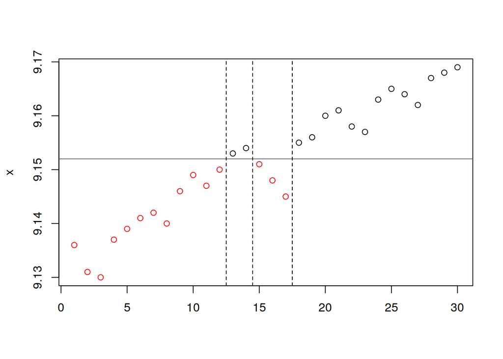

```
##
##  Runs Test
##
## data:  x
## statistic = -4.4593, runs = 4, n1 = 15, n2 = 15, n = 30, p-value =
## 8.221e-06
## alternative hypothesis: nonrandomness
```

```r
randtests::runs.test(x, plot = T)
```

Sekvencia zjavne nie je náhodná, pretože počet skupín nad a pod mediánom nie je dostatočne veľký. Lis na valčeky tak môže byť stále v zábehu, alebo súdiac aj podľa grafu, dochádza k uvoľňovaniu skrutiek a pod.

```r
randtests::turning.point.test(x)
```

```
##
##  Turning Point Test
##
## data:  x
## statistic = -3.6583, n = 31, p-value = 0.0002539
## alternative hypothesis: non randomness
```

Aj test kritických bodov (turning point test) zamietol náhodnosť výberu, pretože kritické hodnoty (lokálne extréme) nie sú dosť početné.

### 4.1.2 Zhoda mediánu jedného výberu

**Príklad:**

Sú k dispozícii záznamy dĺžky volania jedného užívateľa (v minútach).

```r
x <- c(12.8, 3.5, 2.9, 9.4, 8.7, .7, .2, 2.8, 1.9, 2.8, 3.1, 15.8)
```

Testujte (nulovú) hypotézu, že užívateľ nevolá viac ako 3 min. Môžme použit t-test?

```r
stem(x)
```

```
##
##   The decimal point is 1 digit(s) to the right of the |
##
##   0 | 01233334
##   0 | 99
##   1 | 3
##   1 | 6
```

“Stonkovo-lístkový” graf ukazuje veľmi nesymetrické rozdelenie, takže aj bez formálneho testu si môžeme domyslieť, že nebude normálne. Je rozumnejšie použiť neparametrický test.

```r
wilcox.test(x, mu=3, alt="greater", exact = FALSE)
```

```
##
##  Wilcoxon signed rank test with continuity correction
##
## data:  x
## V = 48.5, p-value = 0.2399
## alternative hypothesis: true location is greater than 3
```

Wilcoxonov test patri medzi neparametrické metódy, takže nevyžaduje normalitu náhodného výberu, no pre nesymetrické rozdelenia je vhodnejší znamienkový test (v balíkoch BSDA, DescTools, EnvStats, rstatix)

```r
DescTools::SignTest(x, mu = 3, alt="greater", exact = FALSE)
```

```
##
##  One-sample Sign-Test
##
## data:  x
## S = 6, number of differences = 12, p-value = 0.6128
## alternative hypothesis: true median is greater than 3
## 92.7 percent confidence interval:
##  2.8 Inf
## sample estimates:
## median of the differences
##                         3
```

V každom prípade hypotézu nezamietame, nie je bežné, aby užívateľ volal viac ako 3 minúty.  
Pozn.: Formálne možno symetriu rozdelenia testovať pomocou D’Agostinovho testu

```r
moments::agostino.test(x, alternative = "less")  # iba šikmosť moments::skewness(x)
```

```
##
##  D'Agostino skewness test
##
## data:  x
## skew = 0.95221, z = 1.71974, p-value = 0.04274
## alternative hypothesis: data have positive skewness
```

### 4.1.3 Nezávislosť kvantitatívnej od kvalitatívnej premennej

#### 4.1.3.1 Dva výbery

**Priklad** (8.5, Markechová 2011, str.207)

V rámci ekologického výskumu sa sleduje množstvo olova v dvoch vodných tokoch. Z prvého vodného toku bolo odobratých 6 vzoriek vody a z druhého vodného toku 5 vzoriek vody s týmito nameranými hodnotami olova (v μ g / l ) v 1. vodnom toku: 0,62; 0,54; 0,55; 0,60; 0,53; 0,58 a s týmito nameranými hodnotami olova (v μ g / l ) v 2. vodnom toku: 0,52; 0,56; 0,49; 0,50; 0,51. Pomocou neparametrického testu treba porovnať množstvo olova v týchto dvoch vodných tokoch. Úloha sa da chápať aj ako testovanie nezávislosti dvoch náhod.premenných: X - množstvo olova vo vode, A - vodný tok. Potom sa nás pýtajú, či obsah olova závisí od voľby vodného toku.

```r
tok1 <- c(0.62, 0.54, 0.55, 0.60, 0.53, 0.58); m <- length(tok1)
tok2 <- c(0.52, 0.56, 0.49, 0.50, 0.51); n <- length(tok2)
spolu <- c(tok1, tok2)
T <- rank(spolu); T
```

```
##  [1] 11  6  7 10  5  9  4  8  1  2  3
```

```r
T1 <- sum(T[1:m]); T2 <- sum(T[(m+1):(m+n)])
U1 <- m*n + m*(m+1)/2 - T1
U2 <- m*n + n*(n+1)/2 - T2
c(U1+U2, n*m)  #kontrola
```

```
## [1] 30 30
```

```r
TS <- (U1 - m*n/2)/sqrt(m*n*(m+n+1)/12)
c(test.stat = TS,
  p.value = pnorm(TS)*2
)
```

```
##   test.stat     p.value
## -2.19089023  0.02845974
```

Vstavanou funkciou ako *dvojvýberový* test:

```r
wilcox.test(tok1,tok2)
```

```
##
##  Wilcoxon rank sum exact test
##
## data:  tok1 and tok2
## W = 27, p-value = 0.0303
## alternative hypothesis: true location shift is not equal to 0
```

Vstavanou funkciou ako test *nezávislosti* kvantitatívnej a binárnej premennej (dáta treba najprv transformovať na tzv. dlhý formát):

```r
dat <- data.frame(olovo=c(tok1,tok2), tok=rep(c(1,2), times=c(m,n)))
wilcox.test(olovo ~ tok, data = dat)  # Y ~ A
```

```
##
##  Wilcoxon rank sum exact test
##
## data:  olovo by tok
## W = 27, p-value = 0.0303
## alternative hypothesis: true location shift is not equal to 0
```

Zatiaľčo Mann-Whitney (t.j. nepárový Wilcoxonov) je citlivý hlavne na zmenu v miere polohy rozdelenia (no netestuje rozdiel mediánov, ale medián rozdielov), rozdiel v charaktere dvoch výberov možno otestovať aj komplexnejšie (poloha, rozptyl, tvar rozdelenia) pomocou (Kolmogorov-Smirnov) dvojvýberového testu dobrej zhody

```r
ks.test(tok1, tok2)
```

```
##
##  Two-sample Kolmogorov-Smirnov test
##
## data:  tok1 and tok2
## D = 0.8, p-value = 0.04762
## alternative hypothesis: two-sided
```

V oboch testoch H0 zamietame, množstvo olova závisi od toku.

Overenie predpokladov na použitie citlivejšieho MW testu môžme urobiť napr. Fligner-Killeen testom homogenity rozptylov (nevyžaduje normalitu výberov).

```r
fligner.test(olovo ~ tok, data = dat)
```

```
##
##  Fligner-Killeen test of homogeneity of variances
##
## data:  olovo by tok
## Fligner-Killeen:med chi-squared = 1.6879, df = 1, p-value = 0.1939
```

#### 4.1.3.2 Tri výbery

**Priklad** (Kalina 2010, s.202)

Bola testovaná účinnosť troch druhov insekticídov (A, B, C), výsledkom je počet kusov usmrteného hmyzu v každom pokuse.

- Na hladine významnosti 5% rozhodnite, či všetky tri druhy majú rovnakú účinnosť.
- Ak nie, ktoré druhy sá odlišujú? Použite a) Tukeyho metódu a b) t-test.

```r
A <- c(7,7,4,5)
B <- c(9,10,14,11)
C <- c(6,4,2,4)

dat <- stack(list(A=A, B=B, C=C))
names(dat) <- c("ucinnost", "insekticid")
```

Ak nie je normalita pozorovaní zaručená (napr. príliš malý výber), ANOVA test stráca časť svojej sily a vtedy je vhodnejšia neparametrická alternatíva jednofaktorovej ANOVA v podobe Kruskal-Walisovho testu, ktorý namiesto pôvodných pozorovaní pracuje s ich poradiami:

```r
kruskal.test(ucinnost ~ insekticid, dat)
```

```
##
##  Kruskal-Wallis rank sum test
##
## data:  ucinnost by insekticid
## Kruskal-Wallis chi-squared = 8.4947, df = 2, p-value = 0.0143
```

Na hl.významnosti 5% zamietame nezávislosť účinnosti od druhu insekticídu. Ktoré druhy sa líšia?

```r
tapply(dat$ucinnost, INDEX=dat$insekticid, FUN=median)
```

```
##    A    B    C
##  6.0 10.5  4.0
```

Vyzerá to, že líšiť sa bude asi insekticíd B od ostatných dvoch. Overíme to aplikovaním Wilcoxonovho testu po dvojiciach, treba si len zvoliť metódu korekcie p-hodnoty, napr. tú najznámejšiu - Bonferroniho:

```r
pairwise.wilcox.test(dat$ucinnost, g = dat$insekticid,
                     p.adjust.method = "bonferroni", exact = FALSE)
```

```
##
##  Pairwise comparisons using Wilcoxon rank sum test with continuity correction
##
## data:  dat$ucinnost and dat$insekticid
##
##   A     B
## B 0.088 -
## C 0.541 0.088
##
## P value adjustment method: bonferroni
```

Alebo Dunnov test:

```r
dunn.test::dunn.test(dat$ucinnost, g = dat$insekticid, method = "bonferroni")
```

```
##   Kruskal-Wallis rank sum test
##
## data: x and group
## Kruskal-Wallis chi-squared = 8.4947, df = 2, p-value = 0.01
##
##
##                            Comparison of x by group
##                                  (Bonferroni)
## Col Mean-|
## Row Mean |          A          B
## ---------+----------------------
##        B |  -1.879605
##          |     0.0902
##        C |   0.989266   2.868872
##          |     0.4838    0.0062*
##
## alpha = 0.05
## Reject Ho if p <= alpha/2
```

## 4.2 Odporúčaná literatúra

**Knihy**

- Kalina a kol. (2010) - Základy pravdepodobnosti a matematickej štatistiky (online iba kapitola 11, https://cran.r-project.org/doc/contrib/FundamentalsOfProbAndMStatistics-Slovak.pdf)
- Litschmannová (2011) - Úvod do statistiky (http://mi21.vsb.cz/modul/uvod-do-statistiky)
- Litschmannová - Úvod do statistiky (interaktivní učební text) - Řešené příklady
- Markechová a kol. (2011) - Úvod do štatistiky pre pedagógov (http://www.km.fpv.ukf.sk/upload_publikacie/20120130_90405__1.pdf)
- Markechová a kol. (2011) - Štatistické metódy a ich aplikácie (https://www.researchgate.net/profile/Dagmar_Markechova)